# MOFA Exploration

2026-03-02

# Overview

Multi-Omics Factor Analysis (MOFA) omic layers: transcriptomics, global proteomics, (protein-normalized) phosphoproteomics, (protein-normalized) redox proteomics, and metabolomics.

# Prepare each ome

Features with any missing values are removed, and where multiple features map to the same symbol, the first is kept (or highest-variance for phosphosites, to meet the recommendations of the MOFA tool in picking higher variance features).

**Note: possible complete-case bias:** MOFA input is currently complete data across all samples for each feature. Proteomics and phosphoproteomics contain missing values, so we restrict to complete cases before selecting highly variable features. This may bias the feature set toward higher-abundance proteins or phosphosites that are detected in all samples, and enrichment results should be interpreted with this in mind.

## Transcriptomics

Log-CPM values are computed from raw counts. Ensembl IDs are mapped to human gene symbols via `RAT_TO_HUMAN`.

```r
describe_eset(TRNSCRPT_GN)
```

```
## Features: 14201
## Samples: 50
```

```
##
##          SED 1W 2W 4W 8W
##   Female   5  5  5  5  5
##   Male     5  5  5  5  5
```

```r
gene_symbol_map = RAT_TO_HUMAN %>% select(ensembl, human_symbol)
trnscrpt_mat = cpm(exprs(TRNSCRPT_GN), log = TRUE) %>%
  as.data.frame() %>%
  tibble::rownames_to_column("ensembl") %>%
  left_join(gene_symbol_map, by = "ensembl") %>%
  group_by(human_symbol) %>%
  slice_head(n = 1) %>%
  ungroup() %>%
  filter(!is.na(human_symbol)) %>%
  tibble::column_to_rownames("human_symbol") %>%
  select(-"ensembl") %>%
  as.matrix()

cat("Complete features:", nrow(trnscrpt_mat), "\n")
```

```
## Complete features: 12446
```

## Proteomics

Normalized log2 abundance. Rows with any missing values are dropped.

```r
describe_eset(PROT_GN)
```

```
## Features: 6179
## Samples: 57
```

```
##
##          SED 1W 2W 4W 8W
##   Female   4  6  6  6  6
##   Male     6  6  6  6  5
```

```r
gene_symbol_map = fData(PROT_GN) %>% select(protein_id, gene_symbol)

prot_mat = exprs(PROT_GN) %>%
  as.data.frame() %>%
  tibble::rownames_to_column("protein_id") %>%
  left_join(gene_symbol_map, by = "protein_id") %>%
  group_by(gene_symbol) %>%
  slice_head(n = 1) %>%
  ungroup() %>%
  filter(!is.na(gene_symbol)) %>%
  tibble::column_to_rownames("gene_symbol") %>%
  select(-"protein_id") %>%
  as.matrix()
prot_mat = prot_mat[complete.cases(prot_mat), ]

cat("Complete features:", nrow(prot_mat), "\n")
```

```
## Complete features: 4593
```

## Phosphoproteomics (Protein-Normalized)

Log2 abundance adjusted for global protein changes. Features mapped to rat gene symbols; duplicate sites per gene are resolved by highest variance.

```r
describe_eset(PHOSPHO_GN_NORM)
```

```
## Features: 18161
## Samples: 57
```

```
##
##          SED 1W 2W 4W 8W
##   Female   4  6  6  6  6
##   Male     6  6  6  6  5
```

```r
site_map = fData(PHOSPHO_GN_NORM) %>%
  tibble::rownames_to_column("feature_id") %>%
  mutate(gene_symbol = toupper(gene_symbol),
         gene_site = paste0(gene_symbol, "_", ptm_id)) %>%
  select(feature_id, gene_symbol, gene_site)

phospho_mat = exprs(PHOSPHO_GN_NORM) %>%
  as.data.frame() %>%
  tibble::rownames_to_column("feature_id") %>%
  left_join(site_map, by = "feature_id") %>%
  select(-feature_id) %>%
  filter(!is.na(gene_symbol)) %>%
  # compute per-row variance across expression columns only (- excludes string ID cols)
  # then pick the one site per gene with the highest variance
  mutate(row_var = apply(select(., -gene_site, -gene_symbol), 1, var, na.rm = TRUE)) %>%
  group_by(gene_symbol) %>%
  slice_max(row_var, n=1, with_ties=FALSE) %>%
  ungroup() %>%
  select(-row_var, -gene_symbol) %>%
  tibble::column_to_rownames("gene_site") %>%
  as.matrix()

site_map = site_map %>% filter(gene_site %in% rownames(phospho_mat))
phospho_mat = phospho_mat[complete.cases(phospho_mat), ]

cat("Complete features:", nrow(phospho_mat), "\n")
```

```
## Complete features: 466
```

## Redox Proteomics (Protein-Normalized)

Log2 abundance adjusted for global protein changes. Features mapped to rat gene symbols; duplicate sites per gene are resolved by highest variance.

```r
describe_eset(REDOX_GN_NORM)
```

```
## Features: 11177
## Samples: 57
```

```
##
##          SED 1W 2W 4W 8W
##   Female   4  6  6  6  6
##   Male     6  6  6  6  5
```

```r
redox_feature_map = fData(REDOX_GN_NORM) %>%
  tibble::rownames_to_column("feature_id") %>%
  mutate(gene_symbol = toupper(gene_symbol),
         gene_site = paste0(gene_symbol, "_", ptm_id)) %>%
  select(feature_id, gene_symbol, gene_site)

redox_mat = exprs(REDOX_GN_NORM) %>%
  as.data.frame() %>%
  tibble::rownames_to_column("feature_id") %>%
  left_join(redox_feature_map, by = "feature_id") %>%
  select(-feature_id) %>%
  filter(!is.na(gene_symbol)) %>%
  # compute per-row variance across expression columns only (- excludes string ID cols)
  # then pick the one site per gene with the highest variance
  mutate(row_var = apply(select(., -gene_site, -gene_symbol), 1, var, na.rm = TRUE)) %>%
  group_by(gene_symbol) %>%
  slice_max(row_var, n=1, with_ties=FALSE) %>%
  ungroup() %>%
  select(-row_var, -gene_symbol) %>%
  tibble::column_to_rownames("gene_site") %>%
  as.matrix()

redox_feature_map = redox_feature_map %>% filter(gene_site %in% rownames(redox_mat))

redox_mat = redox_mat[complete.cases(redox_mat), ]

cat("Complete features:", nrow(redox_mat), "\n")
```

```
## Complete features: 1052
```

## Metabolomics

Normalized log2 abundance. Features are mapped to RefMet standardized names; where a metabolite appears in multiple datasets, the higher variance one is picked

```r
describe_eset(METAB_GN)
```

```
## Features: 1215
## Samples: 50
```

```
##
##          SED 1W 2W 4W 8W
##   Female   5  5  5  5  5
##   Male     5  5  5  5  5
```

```r
metab_feature_map = fData(METAB_GN) %>%
  tibble::rownames_to_column("feature_id") %>%
  select(feature_id, refmet_name = metabolite_refmet) %>%
  mutate(refmet_name = toupper(refmet_name))

# How many raw features map to the same refmet name?
repeated_samples = metab_feature_map %>%
  filter(!is.na(refmet_name)) %>%
  count(refmet_name, name = "n_features") %>%
  filter(n_features > 1) %>%
  arrange(desc(n_features))

metab_mat = exprs(METAB_GN) %>%
  as.data.frame() %>%
  tibble::rownames_to_column("feature_id") %>%
  left_join(metab_feature_map, by = "feature_id") %>%
  # select(-feature_id) %>%
  filter(!is.na(refmet_name)) %>%
  mutate(row_var = apply(select(., -feature_id, -refmet_name), 1, var, na.rm = TRUE)) %>%
  group_by(refmet_name) %>%
  slice_max(row_var, n=1, with_ties=FALSE) %>%
  ungroup() %>%
  select(-row_var) %>%
  tibble::column_to_rownames("refmet_name")

metab_da_selected_plat = METAB_GN_DA[["trained_vs_SED"]] %>% filter(featureName %in% metab_mat$feature_id)

metab_mat = metab_mat %>% select(-feature_id) %>% as.matrix()

metab_mat = metab_mat[complete.cases(metab_mat), ]

cat("Complete features:", nrow(metab_mat), "\n")
```

```
## Complete features: 922
```

# Select top variance features

Filter to same number of features per ome

```r
n_features = min(nrow(trnscrpt_mat), nrow(prot_mat), nrow(phospho_mat),
                 nrow(redox_mat), nrow(metab_mat))
cat("Target feature count (set by smallest ome):", n_features, "\n")
```

```
## Target feature count (set by smallest ome): 466
```

```r
trnscrpt_hvf = select_top_var(trnscrpt_mat, n_features)
prot_hvf = select_top_var(prot_mat, n_features)
phospho_hvf = select_top_var(phospho_mat, n_features)
redox_hvf = select_top_var(redox_mat, n_features)
metab_hvf = select_top_var(metab_mat, n_features)

cat("Transcriptomics HVF:", nrow(trnscrpt_hvf), "\n")
```

```
## Transcriptomics HVF: 466
```

```r
cat("Proteomics HVF:", nrow(prot_hvf), "\n")
```

```
## Proteomics HVF: 466
```

```r
cat("Phospho HVF:", nrow(phospho_hvf), "\n")
```

```
## Phospho HVF: 466
```

```r
cat("Redox HVF:", nrow(redox_hvf), "\n")
```

```
## Redox HVF: 466
```

```r
cat("Metabolomics HVF:", nrow(metab_hvf), "\n")
```

```
## Metabolomics HVF: 466
```

# Match samples across omes by pid

Filter to the shared set of animals across all omes (transcriptomics has 5M+5F/timepoint, proteomics/phospho/redox have 6+6; metabolomics has its own sample set).

```r
trnscrpt_hvf = remap_to_pid(trnscrpt_hvf, TRNSCRPT_GN)
prot_hvf = remap_to_pid(prot_hvf, PROT_GN)
phospho_hvf = remap_to_pid(phospho_hvf, PHOSPHO_GN_NORM)
redox_hvf = remap_to_pid(redox_hvf, REDOX_GN_NORM)
# METAB_GN columns are already pid values; no remap needed

shared_pids = Reduce(intersect, list(
  colnames(trnscrpt_hvf),
  colnames(prot_hvf),
  colnames(phospho_hvf),
  colnames(redox_hvf),
  colnames(metab_hvf)
))
cat("Shared samples:", length(shared_pids), "\n")
```

```
## Shared samples: 47
```

```r
trnscrpt_hvf = trnscrpt_hvf[, shared_pids]
prot_hvf = prot_hvf[, shared_pids]
phospho_hvf = phospho_hvf[, shared_pids]
redox_hvf = redox_hvf[, shared_pids]
metab_hvf = metab_hvf[, shared_pids]
```

# Build MOFA object

```r
mofa_data = list(
  Transcriptomics = trnscrpt_hvf,
  Proteomics = prot_hvf,
  Phosphoproteomics = phospho_hvf,
  Redox = redox_hvf,
  Metabolomics = metab_hvf
)

mofa_obj = create_mofa(mofa_data)
```

```
## Creating MOFA object from a list of matrices (features as rows, sample as columns)...
```

```r
mofa_obj
```

```
## Untrained MOFA model with the following characteristics:
##  Number of views: 5
##  Views names: Transcriptomics Proteomics Phosphoproteomics Redox Metabolomics
##  Number of features (per view): 466 466 466 466 466
##  Number of groups: 1
##  Groups names: group1
##  Number of samples (per group): 47
##
```

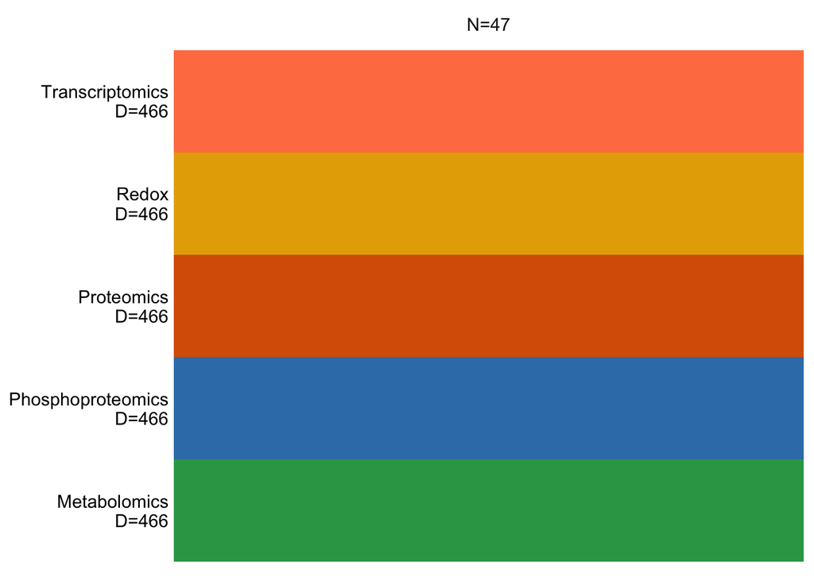

```r
plot_data_overview(mofa_obj)
```

# Add sample metadata

```r
# Build metadata from transcriptomics pData (all omes share pid->sex/timepoint mapping)
pd = pData(TRNSCRPT_GN) %>%
  mutate(pid = as.character(pid)) %>%
  filter(pid %in% shared_pids) %>%
  select(sample = pid, sex, timepoint) %>%
  distinct()

samples_metadata(mofa_obj) = pd
```

# Set MOFA options and train

```r
data_opts = MOFA2::get_default_data_options(mofa_obj)
data_opts$scale_views = TRUE

model_opts = MOFA2::get_default_model_options(mofa_obj)
model_opts$num_factors = 10

train_opts = MOFA2::get_default_training_options(mofa_obj)

mofa_obj = MOFA2::prepare_mofa(
  mofa_obj,
  data_options = data_opts,
  model_options = model_opts,
  training_options = train_opts
)
```

```
## Checking data options...
```

```
## Checking training options...
```

```
## Checking model options...
```

```r
# mofa_trained = MOFA2::run_mofa(mofa_obj,
#                                outfile = file.path(here(), "Other_Figures", "MOFA", "mofa_trained.out"),
#                                use_basilisk = TRUE)

mofa_trained = load_model(
  file.path(here(), "Other_Figures", "MOFA", "mofa_trained.out")
)
```

# Downstream exploration

## Variance explained

Total and per-factor variance explained by each view.

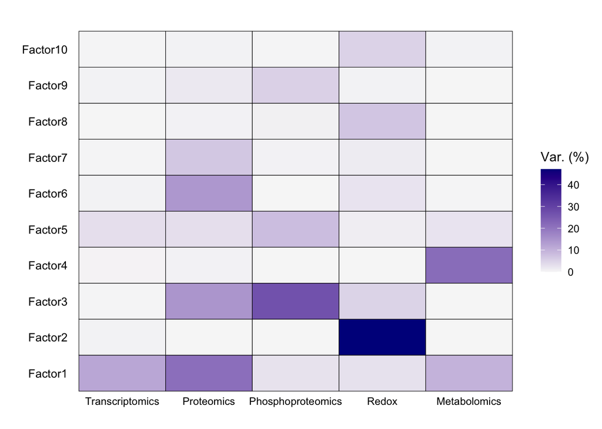

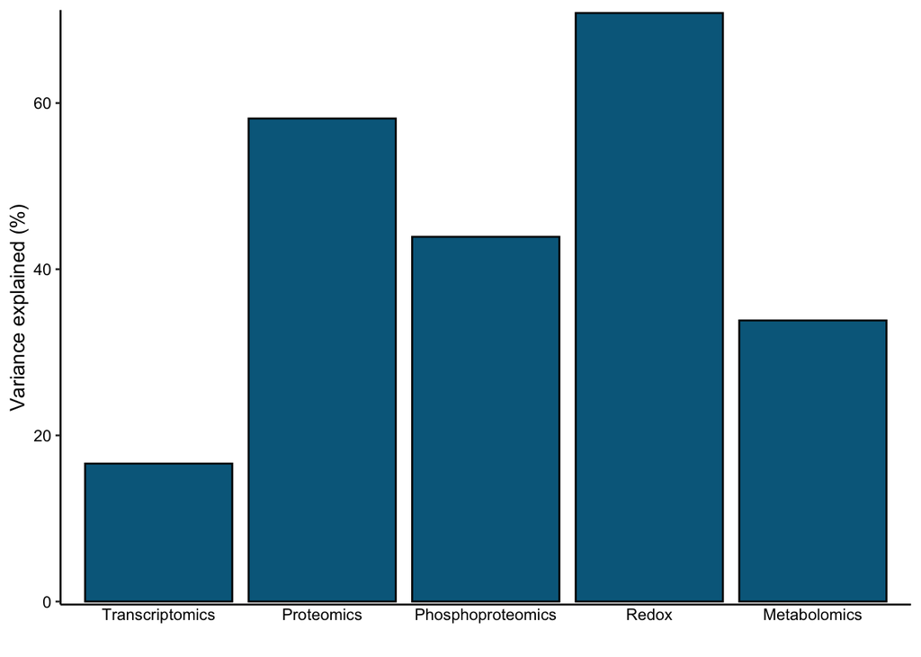

```r
plot_variance_explained(mofa_trained, plot_total = TRUE)
```

## Factor plots

Visualize sample loadings on the first four factors, colored by experimental variables.

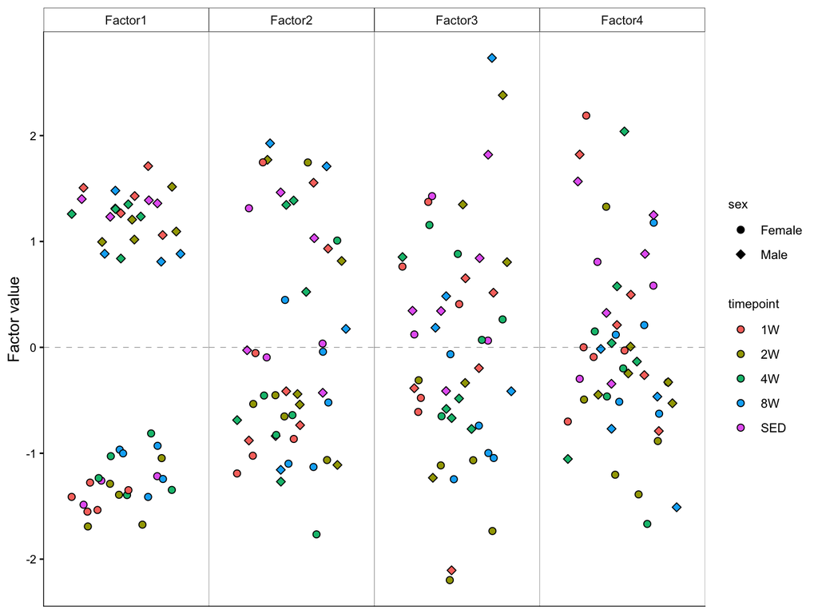

```r
plot_factor(mofa_trained, factors = 1:4, color_by = "timepoint", shape_by = "sex")
```

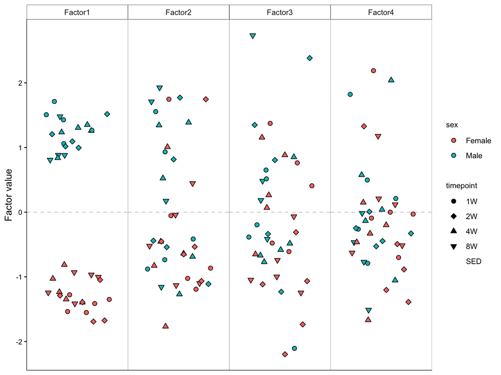

```r
plot_factor(mofa_trained, factors = 1:4, color_by = "sex", shape_by = "timepoint")
```

Factor 1 appears to separate well by sex.

## Factor correlations

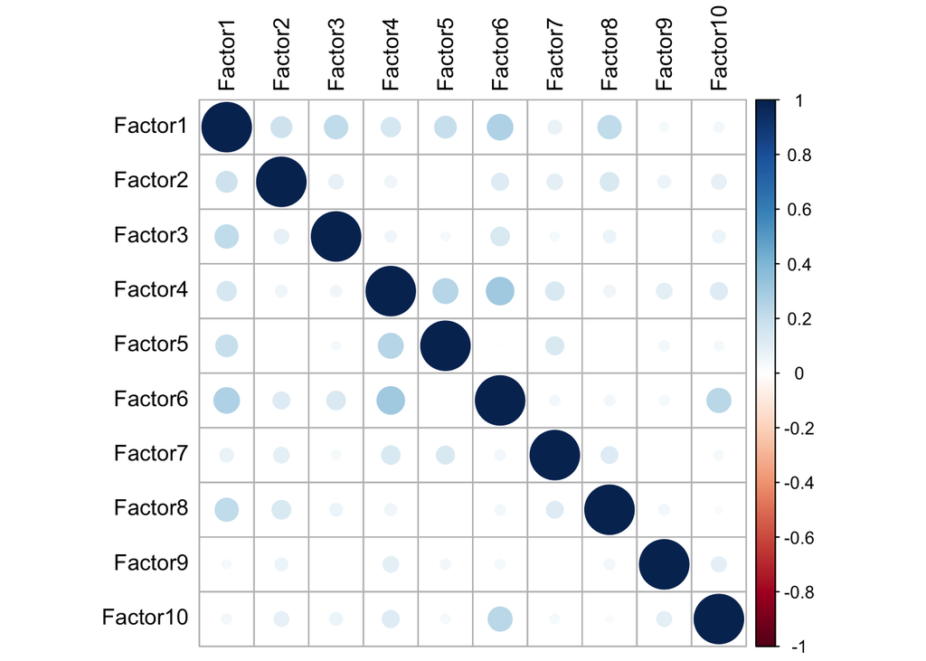

```r
plot_factor_cor(mofa_trained)
```

## Feature weight plots

```
## Saved: /Users/christopherjin/Documents/GitHub/MotrpacRatTraining6moMuscleData/plots/MOFA/factor1_feature_weights.png
```

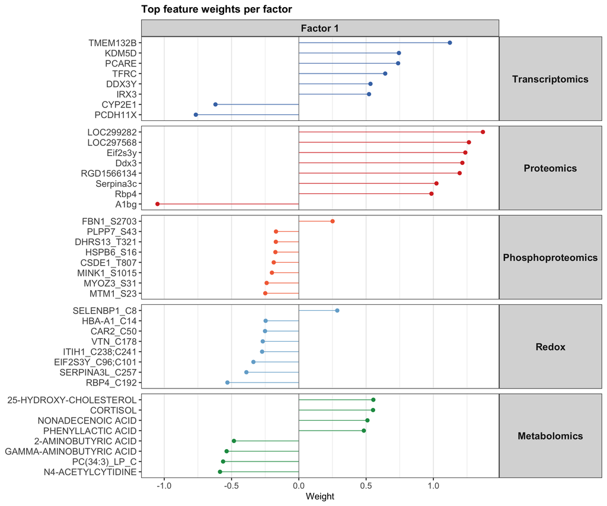

```
## Saved: /Users/christopherjin/Documents/GitHub/MotrpacRatTraining6moMuscleData/plots/MOFA/factor2_feature_weights.png
```

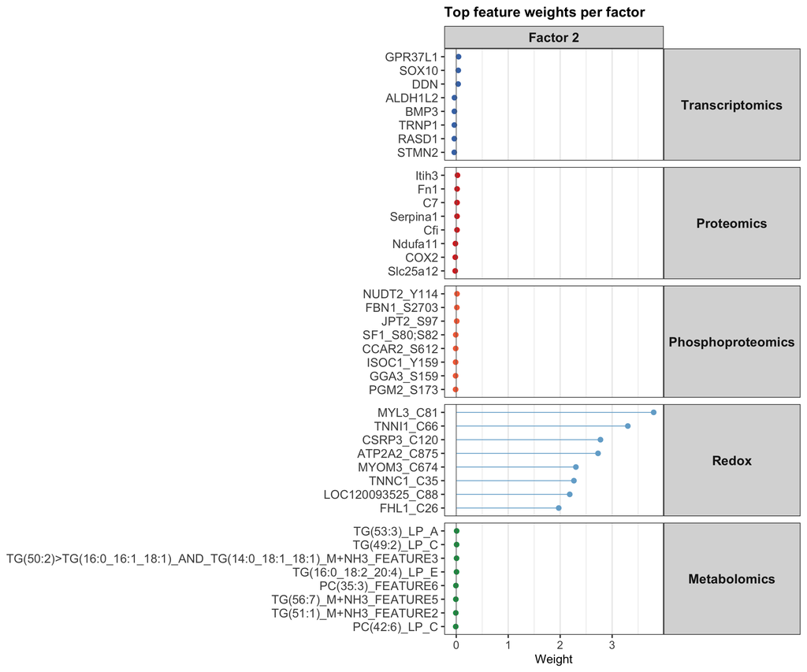

```
## Saved: /Users/christopherjin/Documents/GitHub/MotrpacRatTraining6moMuscleData/plots/MOFA/factor3_feature_weights.png
```

[figure not shown]

```
## Saved: /Users/christopherjin/Documents/GitHub/MotrpacRatTraining6moMuscleData/plots/MOFA/factor4_feature_weights.png
```

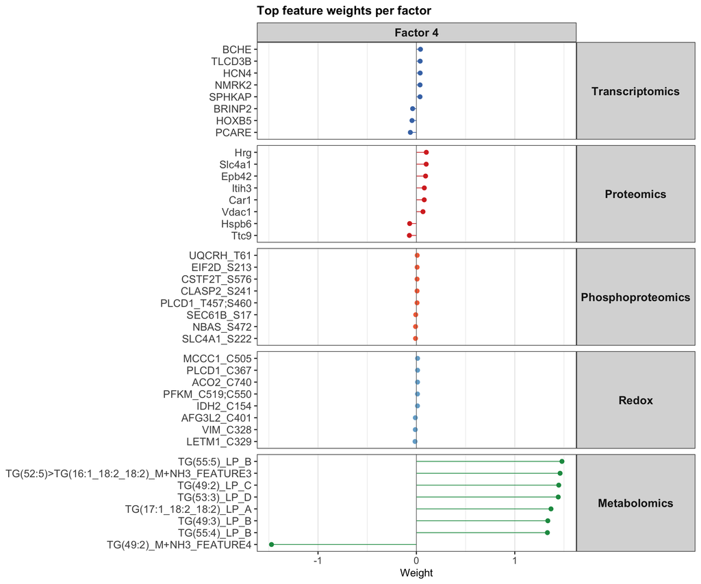

```
## Saved: /Users/christopherjin/Documents/GitHub/MotrpacRatTraining6moMuscleData/plots/MOFA/factor5_feature_weights.png
```

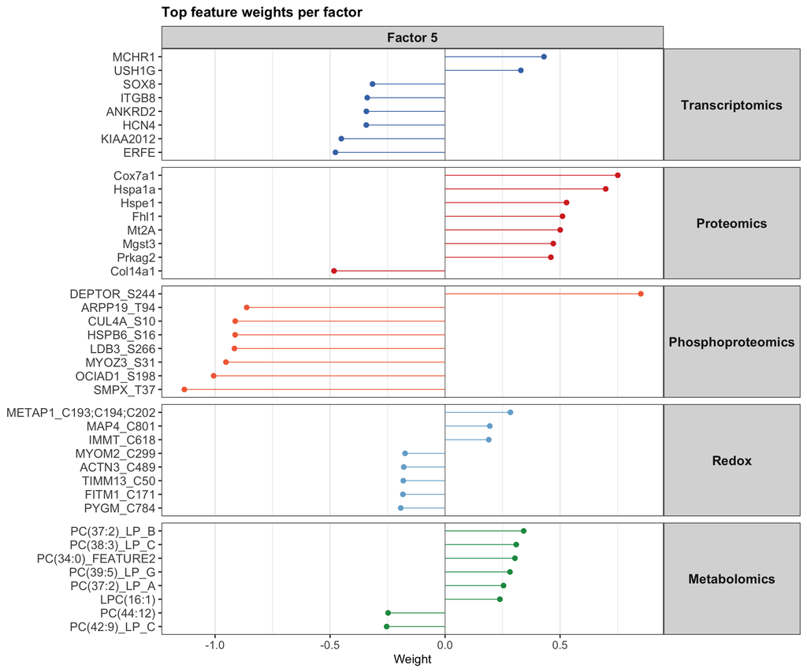

```
## Saved: /Users/christopherjin/Documents/GitHub/MotrpacRatTraining6moMuscleData/plots/MOFA/factor6_feature_weights.png
```

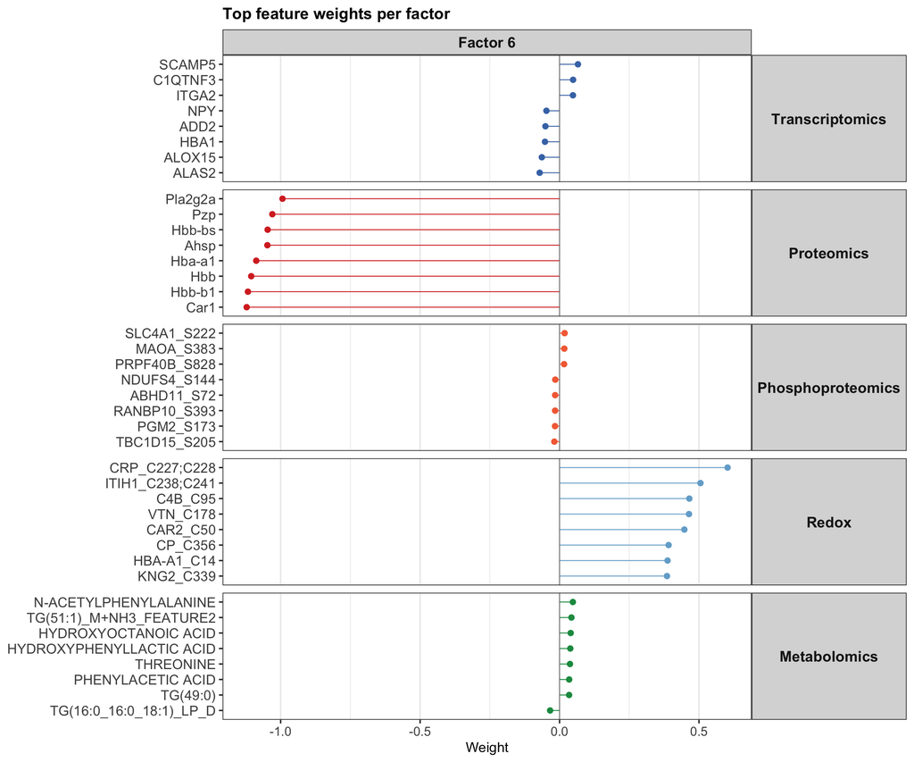

```
## Saved: /Users/christopherjin/Documents/GitHub/MotrpacRatTraining6moMuscleData/plots/MOFA/factor7_feature_weights.png
```

[figure not shown]

```
## Saved: /Users/christopherjin/Documents/GitHub/MotrpacRatTraining6moMuscleData/plots/MOFA/factor8_feature_weights.png
```

[figure not shown]

```
## Saved: /Users/christopherjin/Documents/GitHub/MotrpacRatTraining6moMuscleData/plots/MOFA/factor9_feature_weights.png
```

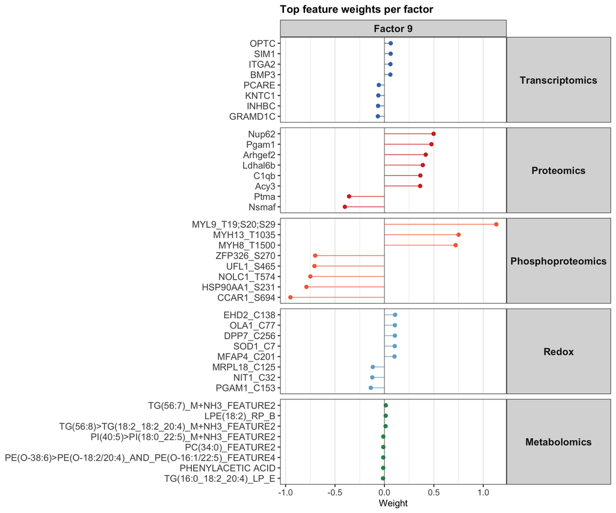

```
## Saved: /Users/christopherjin/Documents/GitHub/MotrpacRatTraining6moMuscleData/plots/MOFA/factor10_feature_weights.png
```

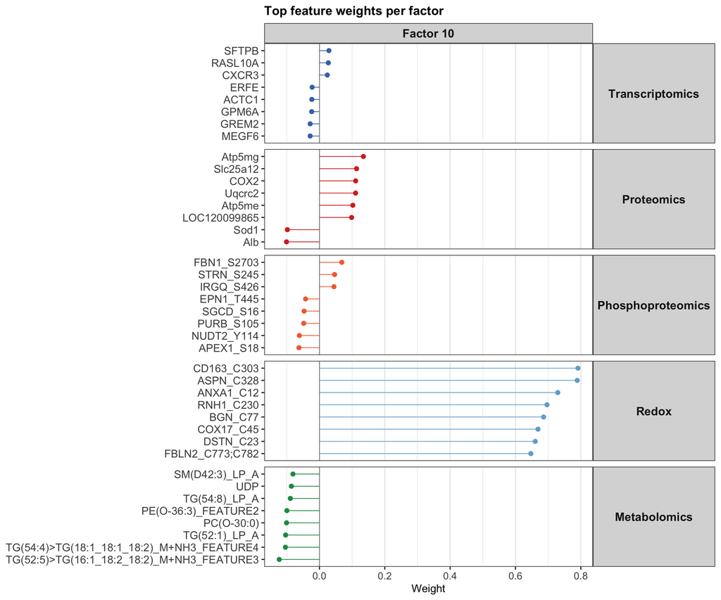

```r
for (f in 1:10) {
  p = plot_feature_weights(mofa_trained,
                              factors = f,
                              n_features = 8,
                              png_path = file.path(here(), "plots", "MOFA", paste0("factor", f, "_feature_weights.png")))
  print(p)
}
```

## Enrichment: Transcriptomics

```r
names = toupper(features_names(mofa_trained)[["Transcriptomics"]])
features_names(mofa_trained)[["Transcriptomics"]] = gsub("_TRANSCRIPTOMICS", "", names)

enrichment_trnscrpt = run_mofa_enrichment(mofa_trained,
                                          view = "Transcriptomics",
                                          feature_sets = trnscrpt_GN_gene_sets,
                                          factors = 1:10,
                                          csv_path = file.path(mofa_out, "enrichment_transcriptomics.csv")
)
```

```
## Intersecting features names in the model and the gene set annotation results in a total of 466 features.
```

```
##
## Running feature set Enrichment Analysis with the following options...
## View: Transcriptomics
## Number of feature sets: 588
## Set statistic: mean.diff
## Statistical test: parametric
```

```
## Subsetting weights with negative sign
```

```
## Intersecting features names in the model and the gene set annotation results in a total of 466 features.
```

```
##
## Running feature set Enrichment Analysis with the following options...
## View: Transcriptomics
## Number of feature sets: 588
## Set statistic: mean.diff
## Statistical test: parametric
```

```
## Subsetting weights with positive sign
```

```
## Enrichment results written to /Users/christopherjin/Documents/GitHub/MotrpacRatTraining6moMuscleData/Other_Figures/MOFA/saved_outputs/enrichment_transcriptomics.csv
## Significant results (padj < 0.05): 75 rows -> /Users/christopherjin/Documents/GitHub/MotrpacRatTraining6moMuscleData/Other_Figures/MOFA/saved_outputs/enrichment_transcriptomics_sig.csv
```

## Enrichment: Proteomics

```r
names = toupper(features_names(mofa_trained)[["Proteomics"]])
features_names(mofa_trained)[["Proteomics"]] = gsub("_PROTEOMICS", "", names)

enrichment_prot = run_mofa_enrichment(mofa_trained,
                                      view = "Proteomics",
                                      feature_sets = prot_GN_gene_sets,
                                      factors = 1:10,
                                      csv_path = file.path(mofa_out, "enrichment_proteomics.csv")
)
```

```
## Intersecting features names in the model and the gene set annotation results in a total of 466 features.
```

```
##
## Running feature set Enrichment Analysis with the following options...
## View: Proteomics
## Number of feature sets: 599
## Set statistic: mean.diff
## Statistical test: parametric
```

```
## Subsetting weights with negative sign
```

```
## Intersecting features names in the model and the gene set annotation results in a total of 466 features.
```

```
##
## Running feature set Enrichment Analysis with the following options...
## View: Proteomics
## Number of feature sets: 599
## Set statistic: mean.diff
## Statistical test: parametric
```

```
## Subsetting weights with positive sign
```

```
## Enrichment results written to /Users/christopherjin/Documents/GitHub/MotrpacRatTraining6moMuscleData/Other_Figures/MOFA/saved_outputs/enrichment_proteomics.csv
## Significant results (padj < 0.05): 575 rows -> /Users/christopherjin/Documents/GitHub/MotrpacRatTraining6moMuscleData/Other_Figures/MOFA/saved_outputs/enrichment_proteomics_sig.csv
```

## Enrichment: Phosphoproteomics

```r
#trim the sites off the names for initial enrichment. then put them back after
phospho_site_names = features_names(mofa_trained)[["Phosphoproteomics"]]
features_names(mofa_trained)[["Phosphoproteomics"]] = sub("_.*", "", toupper(features_names(mofa_trained)[["Phosphoproteomics"]]))

enrichment_phospho = run_mofa_enrichment(mofa_trained,
                                         view = "Phosphoproteomics",
                                         feature_sets = prot_GN_gene_sets,
                                         factors = 1:10,
                                         csv_path = file.path(mofa_out, "enrichment_phosphoproteomics.csv")
)
```

```
## Intersecting features names in the model and the gene set annotation results in a total of 466 features.
```

```
##
## Running feature set Enrichment Analysis with the following options...
## View: Phosphoproteomics
## Number of feature sets: 711
## Set statistic: mean.diff
## Statistical test: parametric
```

```
## Subsetting weights with negative sign
```

```
## Intersecting features names in the model and the gene set annotation results in a total of 466 features.
```

```
##
## Running feature set Enrichment Analysis with the following options...
## View: Phosphoproteomics
## Number of feature sets: 711
## Set statistic: mean.diff
## Statistical test: parametric
```

```
## Subsetting weights with positive sign
```

```
## Enrichment results written to /Users/christopherjin/Documents/GitHub/MotrpacRatTraining6moMuscleData/Other_Figures/MOFA/saved_outputs/enrichment_phosphoproteomics.csv
## Significant results (padj < 0.05): 81 rows -> /Users/christopherjin/Documents/GitHub/MotrpacRatTraining6moMuscleData/Other_Figures/MOFA/saved_outputs/enrichment_phosphoproteomics_sig.csv
```

```r
#and put back the names
features_names(mofa_trained)[["Phosphoproteomics"]] = phospho_site_names
```

## Enrichment: Redox Proteomics

Feature names are rat gene symbols (touppered to match gene sets).

```r
redox_site_names = features_names(mofa_trained)[["Redox"]]
features_names(mofa_trained)[["Redox"]] = sub("_.*", "", toupper(features_names(mofa_trained)[["Redox"]]))

enrichment_redox = run_mofa_enrichment(mofa_trained,
                                       view = "Redox",
                                       feature_sets = prot_GN_gene_sets,
                                       factors = 1:10,
                                       csv_path = file.path(mofa_out, "enrichment_redox.csv")
)
```

```
## Intersecting features names in the model and the gene set annotation results in a total of 466 features.
```

```
##
## Running feature set Enrichment Analysis with the following options...
## View: Redox
## Number of feature sets: 614
## Set statistic: mean.diff
## Statistical test: parametric
```

```
## Subsetting weights with negative sign
```

```
## Intersecting features names in the model and the gene set annotation results in a total of 466 features.
```

```
##
## Running feature set Enrichment Analysis with the following options...
## View: Redox
## Number of feature sets: 614
## Set statistic: mean.diff
## Statistical test: parametric
```

```
## Subsetting weights with positive sign
```

```
## Enrichment results written to /Users/christopherjin/Documents/GitHub/MotrpacRatTraining6moMuscleData/Other_Figures/MOFA/saved_outputs/enrichment_redox.csv
## Significant results (padj < 0.05): 258 rows -> /Users/christopherjin/Documents/GitHub/MotrpacRatTraining6moMuscleData/Other_Figures/MOFA/saved_outputs/enrichment_redox_sig.csv
```

```r
features_names(mofa_trained)[["Redox"]] = redox_site_names
```

## Enrichment: Metabolomics

Feature names are RefMet standardized names (touppered to match refmet sets).

```r
features_names(mofa_trained)[["Metabolomics"]] = toupper(features_names(mofa_trained)[["Metabolomics"]])

enrichment_metab = run_mofa_enrichment(mofa_trained,
                                       view = "Metabolomics",
                                       feature_sets = metab_GN_refmet_sets,
                                       factors = 1:10,
                                       csv_path = file.path(mofa_out, "enrichment_metabolomics.csv")
)
```

```
## Intersecting features names in the model and the gene set annotation results in a total of 466 features.
```

```
##
## Running feature set Enrichment Analysis with the following options...
## View: Metabolomics
## Number of feature sets: 7
## Set statistic: mean.diff
## Statistical test: parametric
```

```
## Subsetting weights with negative sign
```

```
## Intersecting features names in the model and the gene set annotation results in a total of 466 features.
```

```
##
## Running feature set Enrichment Analysis with the following options...
## View: Metabolomics
## Number of feature sets: 7
## Set statistic: mean.diff
## Statistical test: parametric
```

```
## Subsetting weights with positive sign
```

```
## Enrichment results written to /Users/christopherjin/Documents/GitHub/MotrpacRatTraining6moMuscleData/Other_Figures/MOFA/saved_outputs/enrichment_metabolomics.csv
## Significant results (padj < 0.05): 12 rows -> /Users/christopherjin/Documents/GitHub/MotrpacRatTraining6moMuscleData/Other_Figures/MOFA/saved_outputs/enrichment_metabolomics_sig.csv
```

## Cross-ome enrichment: faceted per factor

```r
all_enrichments = list(
  Transcriptomics = enrichment_trnscrpt,
  Proteomics = enrichment_prot,
  # Phosphoproteomics = enrichment_phospho,
  Redox = enrichment_redox,
  Metabolomics = enrichment_metab
)
```

```r
sig_all = load_sig_enrichments(mofa_out)
```

```
## Saved: /Users/christopherjin/Documents/GitHub/MotrpacRatTraining6moMuscleData/plots/MOFA/factor1.png
```

[figure not shown]

```
## Saved: /Users/christopherjin/Documents/GitHub/MotrpacRatTraining6moMuscleData/plots/MOFA/factor2.png
```

[figure not shown]

```
## Saved: /Users/christopherjin/Documents/GitHub/MotrpacRatTraining6moMuscleData/plots/MOFA/factor3.png
```

[figure not shown]

```
## Saved: /Users/christopherjin/Documents/GitHub/MotrpacRatTraining6moMuscleData/plots/MOFA/factor4.png
```

[figure not shown]

```
## Saved: /Users/christopherjin/Documents/GitHub/MotrpacRatTraining6moMuscleData/plots/MOFA/factor5.png
```

[figure not shown]

```
## Saved: /Users/christopherjin/Documents/GitHub/MotrpacRatTraining6moMuscleData/plots/MOFA/factor6.png
```

[figure not shown]

```
## Saved: /Users/christopherjin/Documents/GitHub/MotrpacRatTraining6moMuscleData/plots/MOFA/factor7.png
```

[figure not shown]

```
## Saved: /Users/christopherjin/Documents/GitHub/MotrpacRatTraining6moMuscleData/plots/MOFA/factor8.png
```

[figure not shown]

```
## Saved: /Users/christopherjin/Documents/GitHub/MotrpacRatTraining6moMuscleData/plots/MOFA/factor9.png
```

[figure not shown]

```
## Saved: /Users/christopherjin/Documents/GitHub/MotrpacRatTraining6moMuscleData/plots/MOFA/factor10.png
```

[figure not shown]

```r
for (f in 1:10) {
  p = plot_enrichment_faceted(all_enrichments,
                              factor = f,
                              max_pathways = 8,
                              png_path = file.path(here(), "plots", "MOFA", paste0("factor", f, ".png")))
  print(p)
}
```

## Combined enrichment bubble heatmap

Bubble heatmap across all views and factors. Each row is a top significant gene set; columns are factors. Circle size = -log10(padj) (capped at 5 mm), circle color = signed -log10(padj) (red = up-weighted, blue = down-weighted), grey background = padj < 0.05.

```r
# Compute global signed -log10(padj) range for a shared colour scale
compute_signed_logp = function(enrich, n_top=8, padj_threshold=0.05) {
  factor_cols = intersect(colnames(enrich$up$pval.adj),
                          colnames(enrich$down$pval.adj))
  pu = enrich$up$pval.adj[, factor_cols, drop=FALSE]
  pd = enrich$down$pval.adj[, factor_cols, drop=FALSE]
  min_p = pmin(apply(pu, 1, min, na.rm=TRUE), apply(pd, 1, min, na.rm=TRUE))
  sig = names(sort(min_p[min_p < padj_threshold]))[seq_len(min(n_top, sum(min_p < padj_threshold)))]
  if (length(sig) == 0) return(numeric(0))
  as.vector(ifelse(pu[sig, , drop=FALSE] <= pd[sig, , drop=FALSE],
                   -log10(pu[sig, , drop=FALSE]),
                   log10(pd[sig, , drop=FALSE])))
}

all_vals = unlist(lapply(all_enrichments, compute_signed_logp))
max_abs_logp = min(max(abs(all_vals), na.rm=TRUE), 20)

col_fun_enrich = circlize::colorRamp2(
  c(-max_abs_logp, 0, max_abs_logp),
  c("#3366ff", "white", "darkred")
)

ome_cols_mofa = c(
  Transcriptomics="#4575b4",
  Proteomics="#d73027",
  Phosphoproteomics="#f46d43",
  Redox="#74add1",
  Metabolomics="#1a9850"
)

color_lg = ComplexHeatmap::Legend(
  title="-log10(padj)\n(+ up, \u2212 down)",
  col_fun=col_fun_enrich,
  at=c(-round(max_abs_logp), 0, round(max_abs_logp)),
  legend_height=grid::unit(4, "cm")
)
ome_lg = ComplexHeatmap::Legend(
  title="View",
  at=names(ome_cols_mofa),
  legend_gp=grid::gpar(fill=ome_cols_mofa)
)
sig_lg = ComplexHeatmap::Legend(
  title="Significance",
  at="padj < 0.05",
  legend_gp=grid::gpar(fill="grey90", col=NA)
)

enrich_heatmaps = list()
for (v in names(all_enrichments)) {
  ht = make_mofa_enrichment_heatmap(
    enrichment=all_enrichments[[v]],
    view_name=v,
    ome_cols=ome_cols_mofa,
    col_fun=col_fun_enrich,
    n_top=8
  )
  if (!is.null(ht)) enrich_heatmaps[[v]] = ht
}

if (length(enrich_heatmaps) > 0) {
  combined_enrich = Reduce(`%v%`, enrich_heatmaps)
  png_path = file.path(here(), "plots", "MOFA", "enrichment_bubble_heatmap.png")
  png(png_path, width=12, height=10, units="in", res=600)
  ComplexHeatmap::draw(
    combined_enrich,
    heatmap_legend_list=list(color_lg, ome_lg, sig_lg),
    merge_legend=TRUE,
    heatmap_legend_side="left"
  )
  dev.off()
  cat("Saved:", png_path, "\n")
}
```

```
## Saved: /Users/christopherjin/Documents/GitHub/MotrpacRatTraining6moMuscleData/plots/MOFA/enrichment_bubble_heatmap.png
```

## Feature heatmaps

```r
phospho_mofa_to_da = function(mofa_features) {
  m = site_map %>%
    dplyr::filter(gene_site %in% mofa_features)
  setNames(m$feature_id, m$gene_site)
}

redox_mofa_to_da = function(mofa_features){
  m = redox_feature_map %>%
    dplyr::filter(gene_site %in% mofa_features)
  setNames(m$feature_id, m$gene_site)
}

view_da = list(
  Transcriptomics = TRNSCRPT_GN_DA[["trained_vs_SED"]],
  Proteomics = PROT_GN_DA[["trained_vs_SED"]] %>% filter(!is.na(description)),
  Phosphoproteomics = PHOSPHO_GN_DA[["trained_vs_SED"]],
  Redox = REDOX_GN_NORM_DA[["trained_vs_SED"]],
  Metabolomics = metab_da_selected_plat #see above -> need to make sure i filter to the specific platforms i use.
)

view_gene_map = list(
  Transcriptomics = NULL,
  Proteomics = NULL,
  Phosphoproteomics = phospho_mofa_to_da,
  Redox = redox_mofa_to_da,
  Metabolomics = NULL
)

for (f in 1:10) {
  ht = mofa_feature_heatmap(mofa_trained,
                            factor_num=f,
                            view_da=view_da,
                            view_gene_map=view_gene_map,
                            n=8,
                            scale=3,
                            view_feature_col=list(Transcriptomics = "gene_symbol",
                                                  Proteomics = "gene_symbol",
                                                  Metabolomics="metabolite_refmet"))
  if (!is.null(ht)) {
    png_path = file.path(here(), "plots", "MOFA", paste0("factor", f, "_heatmap.png"))
    png(png_path, width=10, height=12, units="in", res=600)
    ComplexHeatmap::draw(ht, merge_legend=TRUE,
                         column_title=paste0("Factor ", f),
                         column_title_gp=grid::gpar(fontsize=14, fontface="bold"))
    dev.off()
    cat("Saved:", png_path, "\n")
  }
}
```